[output not shown]

Question 3.1 (a)

If we do not do a set.seed, we can see there is quite a bit of variation in model performance from run-to-run as the random sampling changes, which shows there is a relatively high amount of random patterns in the data.

```r
library(kernlab)
library(kknn)
library(dplyr)
data <- read.table("C:/Users/namee/Documents/Masters/ISYE6501 - Intro Analytics Modelling/HW2/credit_card_data.txt", stringsAsFactors = FALSE, header = FALSE)

#split data into 80% train/validate & 20% test via random sampling
s <- sample(nrow(data),524)
train_val <- data[s,]
test <- data[-s,]

#Split data into k-sets------------------------------------------
k <- 4

#define number of rows for each kth set
set_size <- nrow(train_val)/k
print(set_size)
```

```
## [1] 131
```

```r
#initialize vector of length k to store created sets
sets <- list()

#initialize empty df for storing rows already utilized for a set
sampled <- train_val[0,]

#loop through data to split into k sets
for(i in 1:k){
  #subtract already sampled data to get unused data for creating next set
  unsampled <- anti_join(train_val,sampled)

  set.seed(1)
  s <- sample(nrow(unsampled),set_size)
  set <- unsampled[s,]

  sets[[i]] <- set

  #update df of utilized data with recently created set
  sampled <- rbind.data.frame(sampled,set)
}
#train & validate--------------------------------------------------

#setup empty df to record accuracies
avg_accuracies <- data.frame(k=c(),accuracy=c())

for(k_val in 5:20){

  #initiate results vector to store accuracy for each k-fold
  fold_accuracies <- vector()

  for(i in 1:length(sets)){
    data_train <- do.call(rbind,sets[-i])
    data_valid <- sets[[i]]
    model <- kknn(V11~., data_train, data_valid, k=k_val, kernel="optimal", scale=TRUE)
    result <- round(model$fitted.values)

    #append prediction accuracy of this foldto vector
    fold_accuracies <- rbind(fold_accuracies,sum(result == data_valid[,11]) / nrow(data_valid))
  }

  #average accuracy over k-folds and store in df with corresponding k-value
  avg_accuracy <- data.frame(k_val,mean(fold_accuracies))

  #append to df with all k-values
  avg_accuracies <- rbind(avg_accuracies,avg_accuracy)
}

print(avg_accuracies)
```

```
##    k_val mean.fold_accuracies.
## 1      5             0.8339695
## 2      6             0.8416031
## 3      7             0.8435115
## 4      8             0.8435115
## 5      9             0.8435115
## 6     10             0.8435115
## 7     11             0.8435115
## 8     12             0.8473282
## 9     13             0.8492366
## 10    14             0.8492366
## 11    15             0.8511450
## 12    16             0.8549618
## 13    17             0.8492366
## 14    18             0.8511450
## 15    19             0.8530534
## 16    20             0.8568702
```

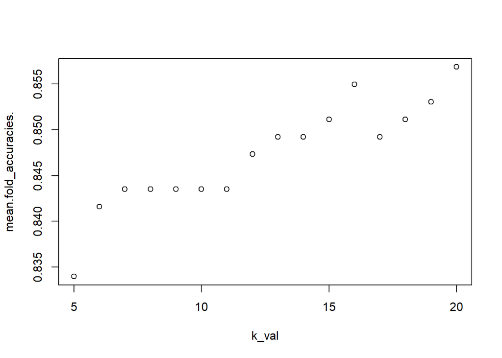

```r
plot(avg_accuracies)
```

```r
#train on entire train_val dataset with chosen model-------------------------
model <- kknn(V11~., train_val, test, k=6, kernel="optimal", scale=TRUE)
result <- round(model$fitted.values)
accuracy <- sum(result == test[,11])/nrow(test)
print(accuracy)
```

```
## [1] 0.8615385
```

Question 3.1 (b)

Using a 60/20/20 split of train/validate/test to choose and test a kknn model, we find a k-value of 10, 11, or 12 to yield the best results of 87.02290%, again with a high variability in between runs. On the test set, this results in an accuracy of 84.61538%.

```
##     i sum.result....val...11...nrow.val.
## 1   5                          0.8167939
## 2   6                          0.8320611
## 3   7                          0.8473282
## 4   8                          0.8473282
## 5   9                          0.8396947
## 6  10                          0.8702290
## 7  11                          0.8702290
## 8  12                          0.8702290
## 9  13                          0.8625954
## 10 14                          0.8625954
## 11 15                          0.8625954
## 12 16                          0.8549618
## 13 17                          0.8549618
## 14 18                          0.8625954
## 15 19                          0.8625954
## 16 20                          0.8625954
```

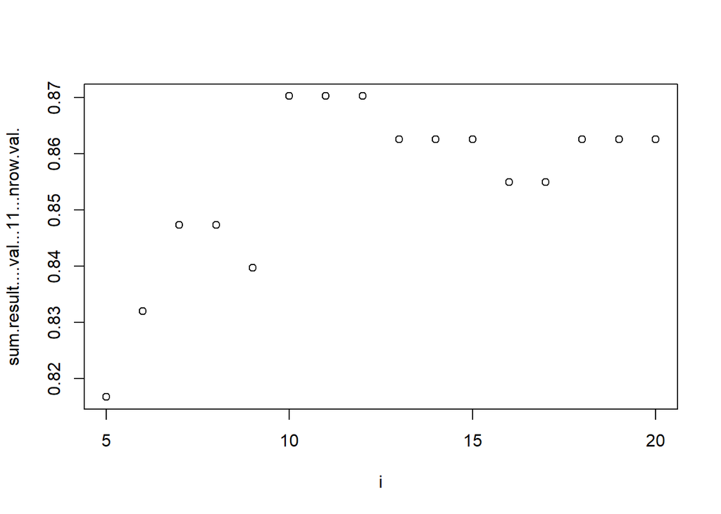

```
## [1] 0.8461538
```

Question 4.2

I looped through various k values and different combinations of predictor columns (where 1=column1 in the iris dataset, 2=column2 etc.)

To measure how each kmeans algorithm performed, I chose the tot.withinss distance metric as it matches the formula provided in class for minimizing distance between clusters and their data points.

Looking at our distance-clusters graphs, k=3 seems to consistently show where the kink starts, meaning it is the best k to choose before we see diminishing returns.

Looking at our “k vs distance vs predictors” graph, we see relationship between columns 2,4 seems to fair the best with minimum distance given any number of clusters.

Then, looking at the different predictor combinations that include both columns 2 and 4, we have [2,4] or [2,3,4].

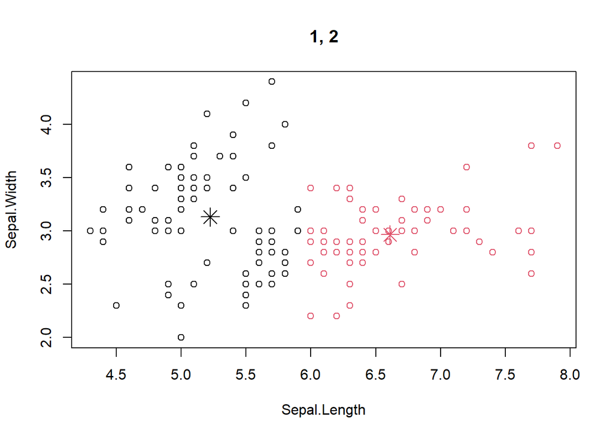

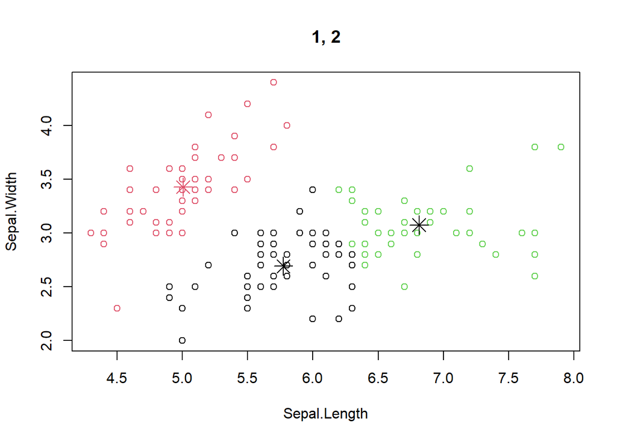

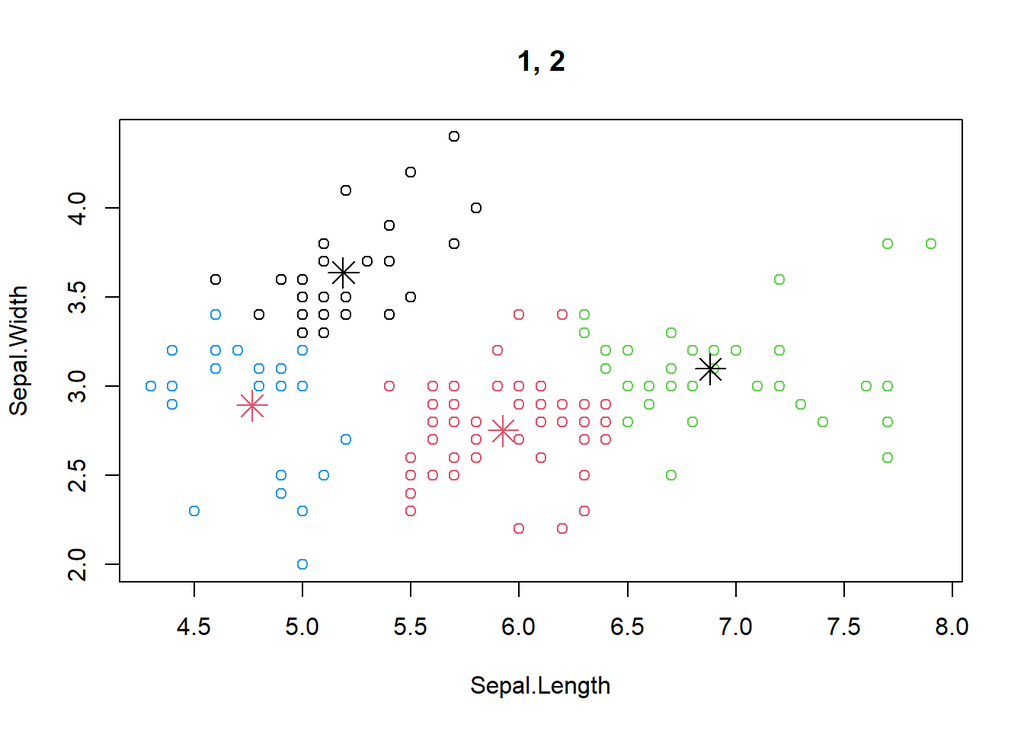

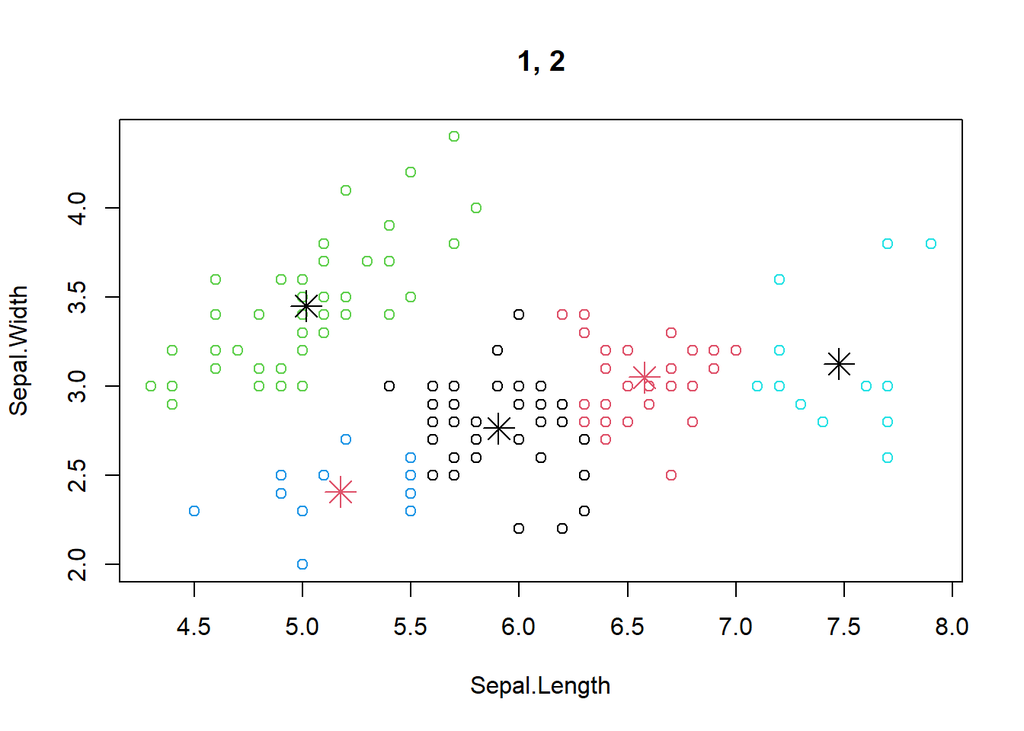

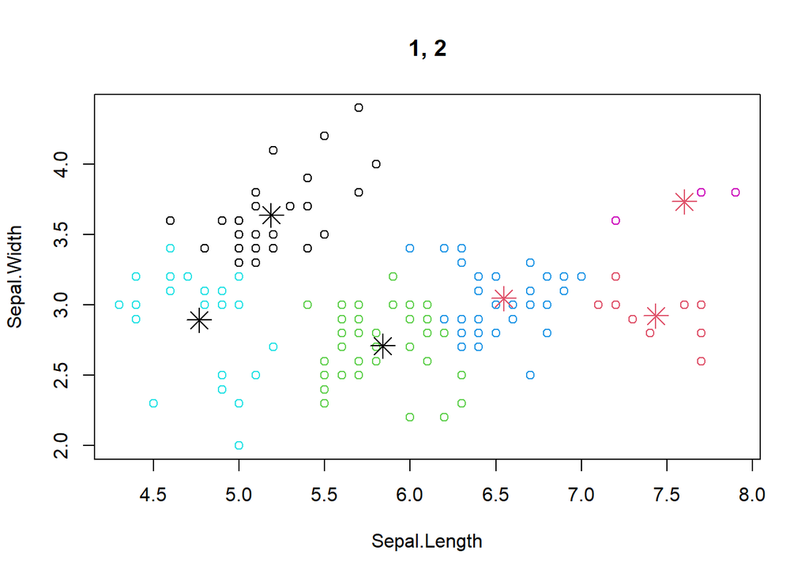

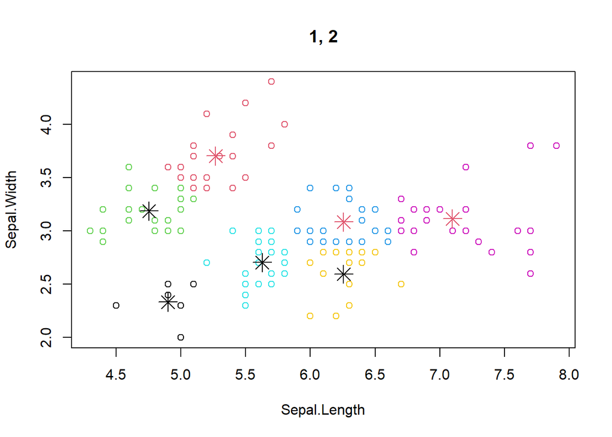

```
## [1] 6
```

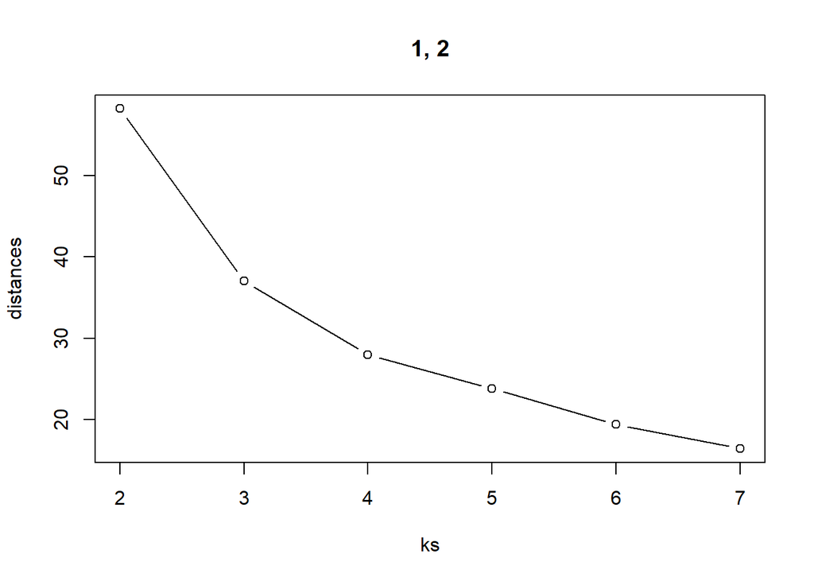

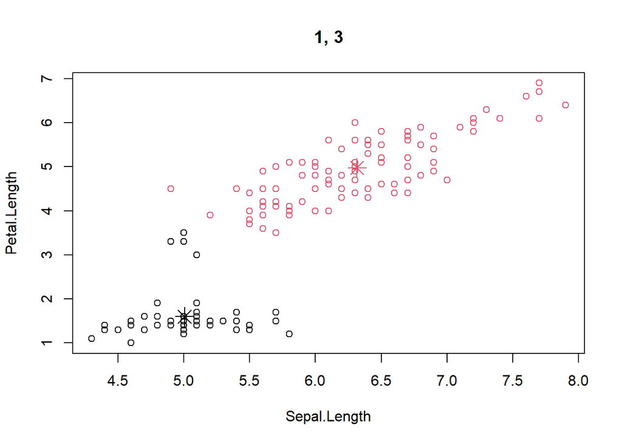

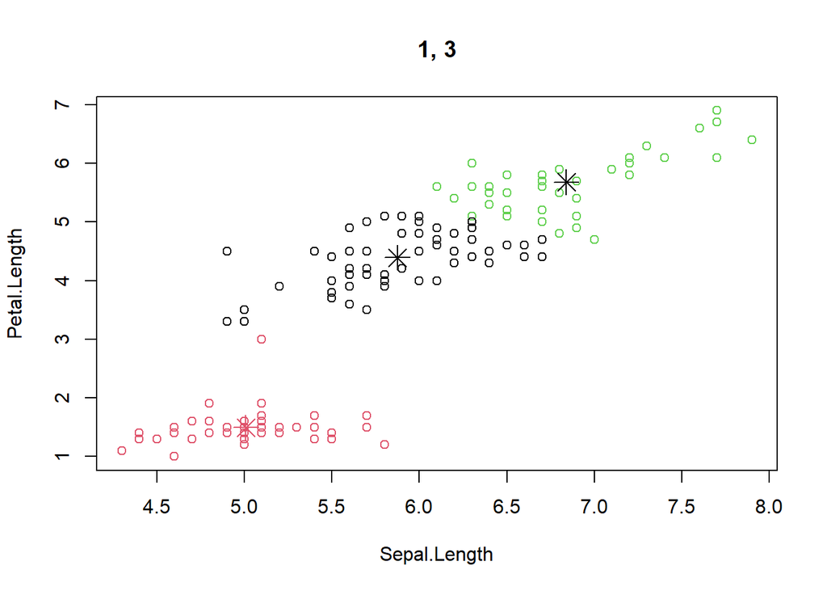

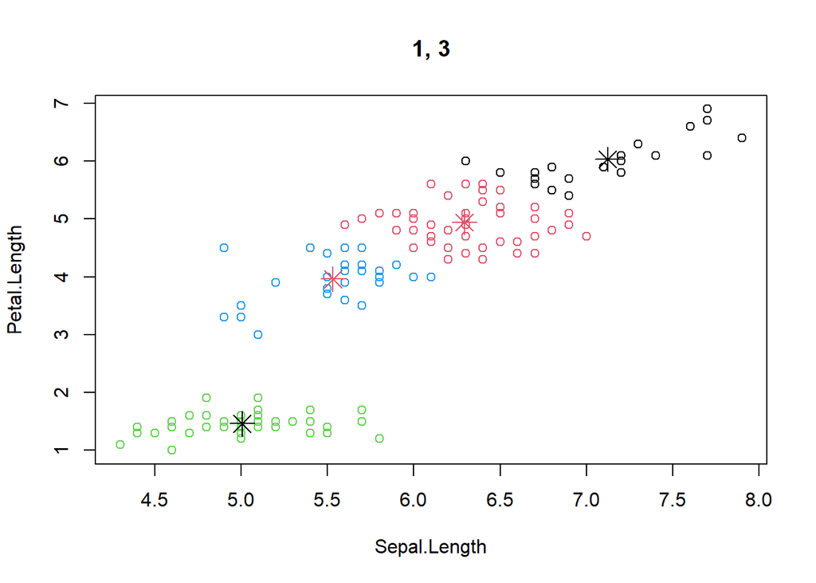

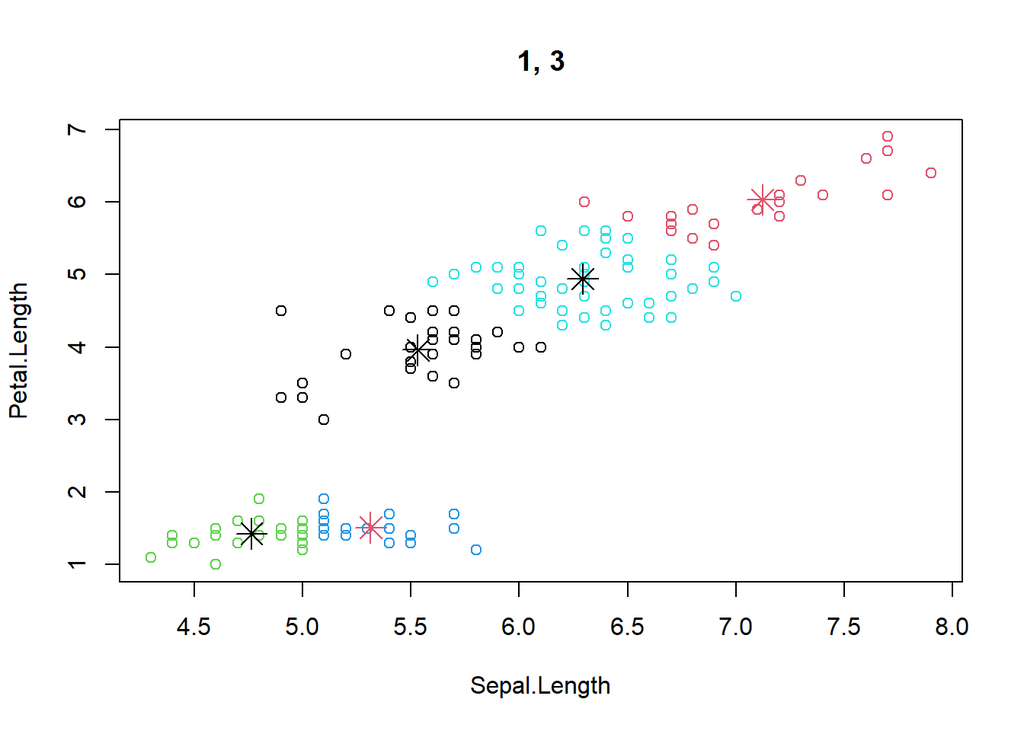

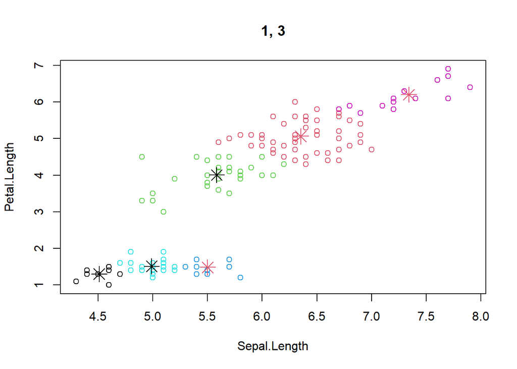

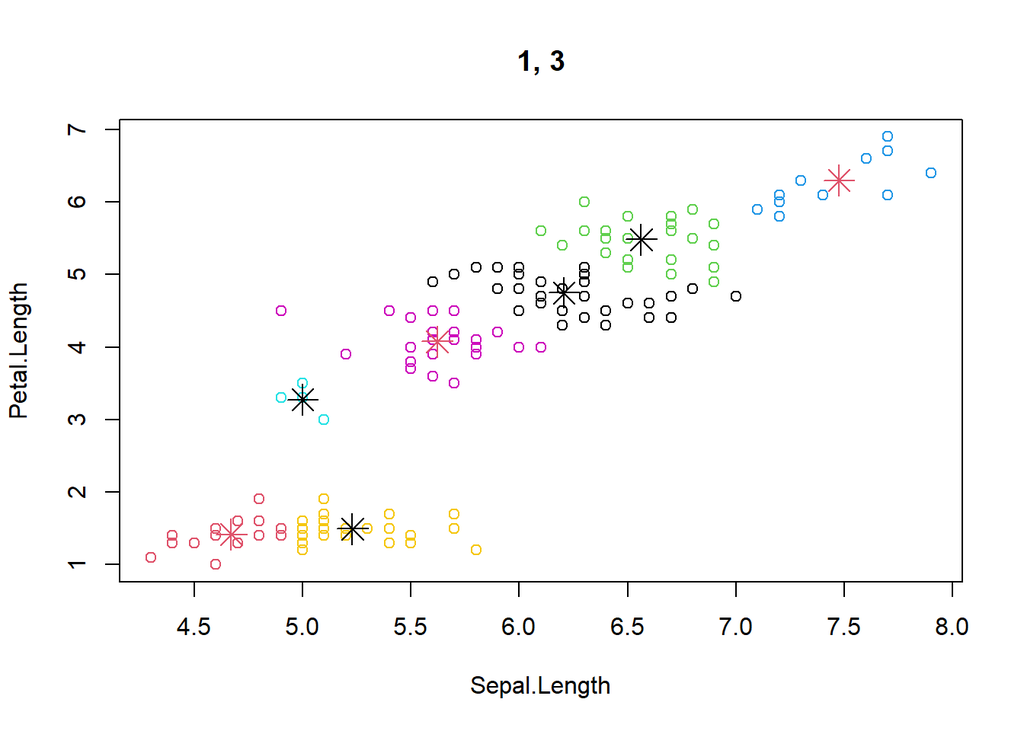

```
## [1] 6
```

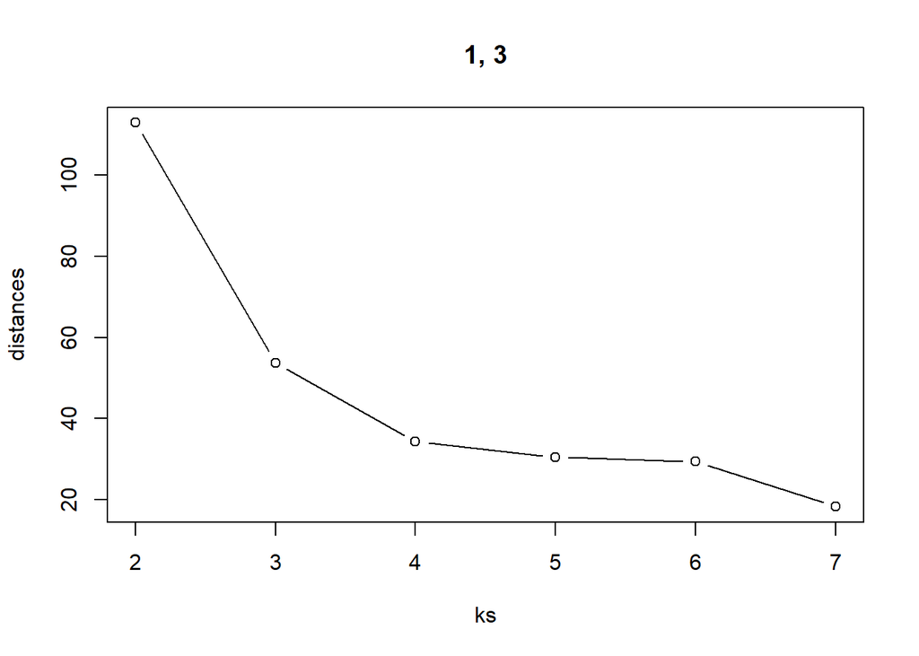

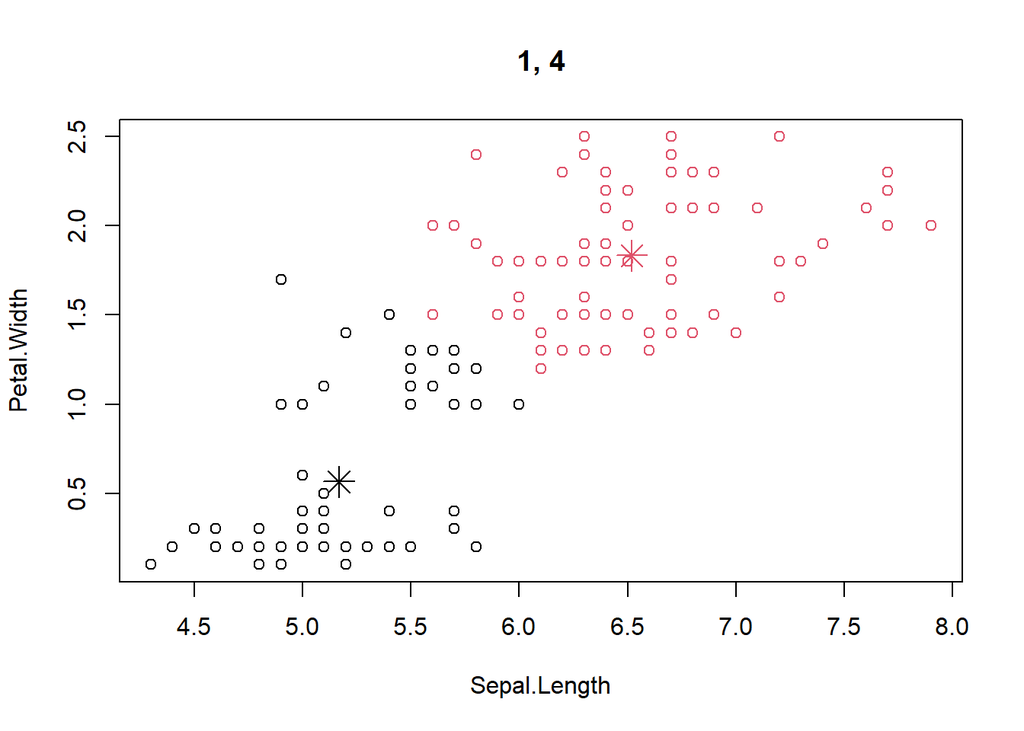

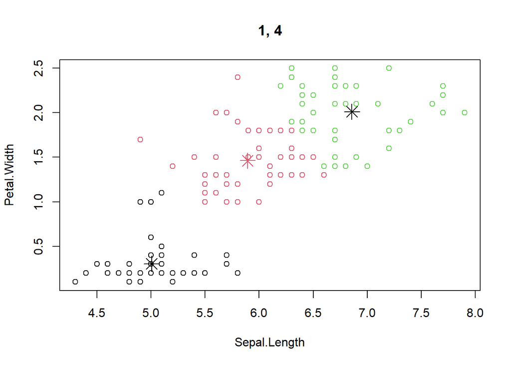

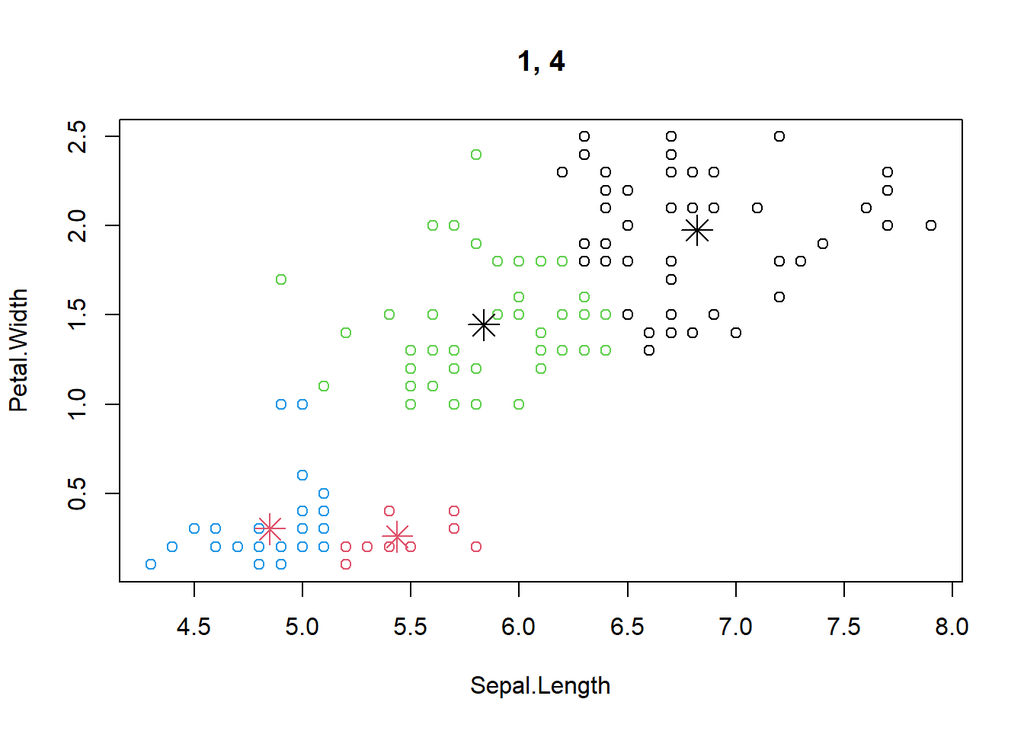

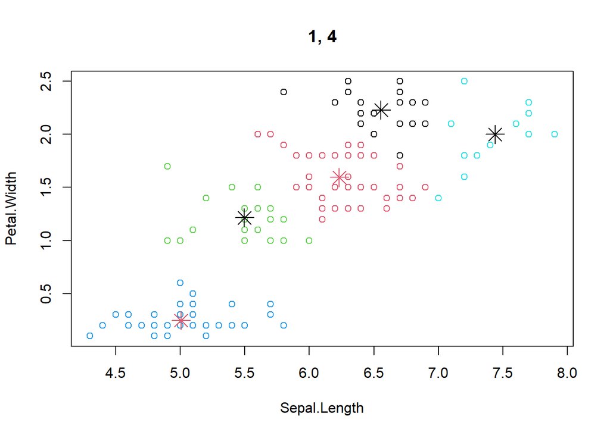

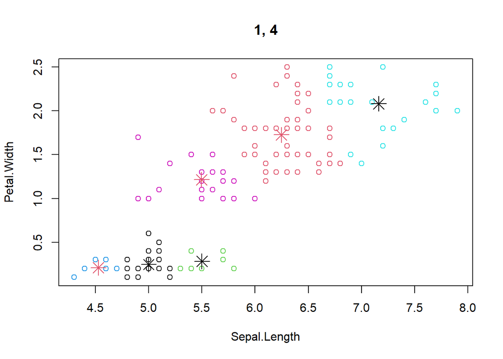

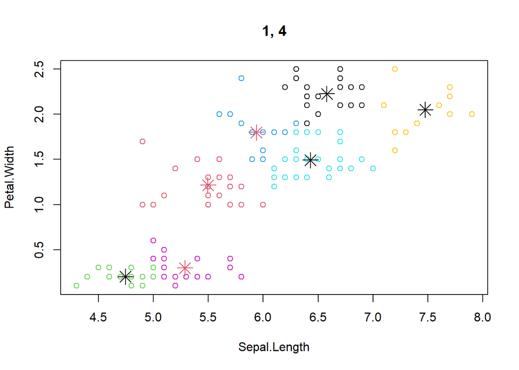

```
## [1] 6
```

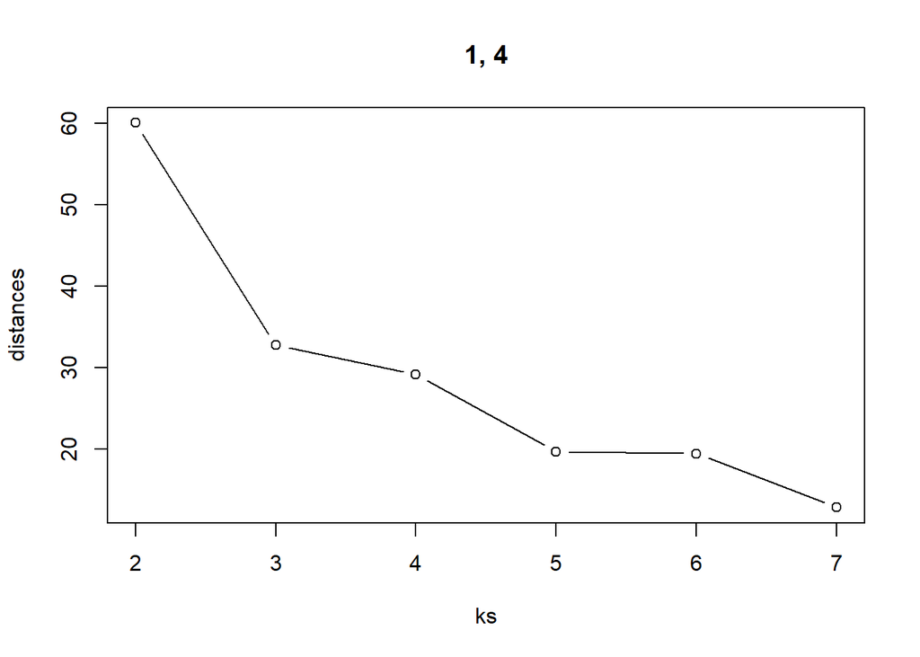

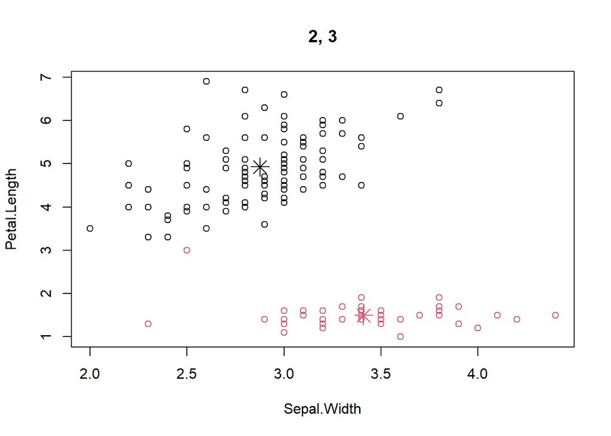

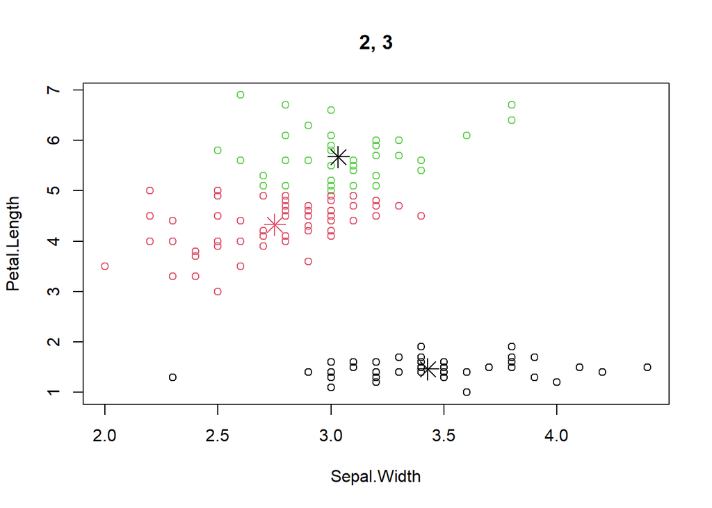

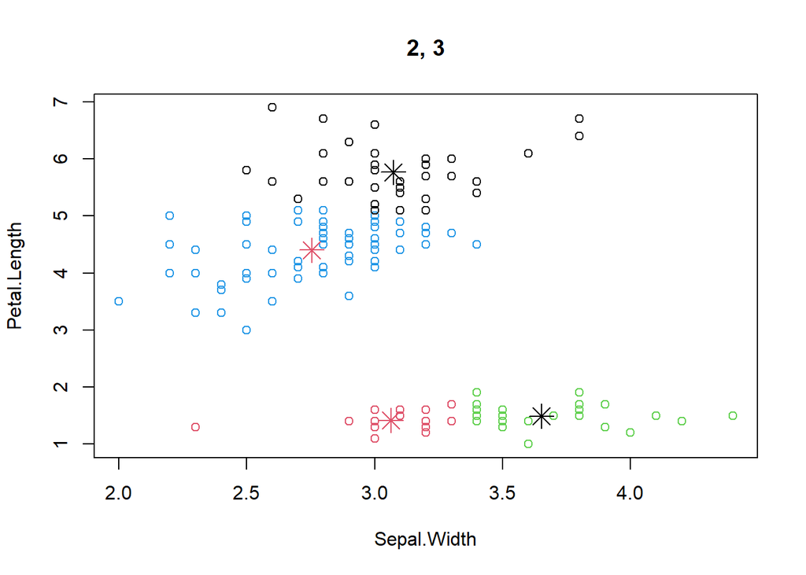

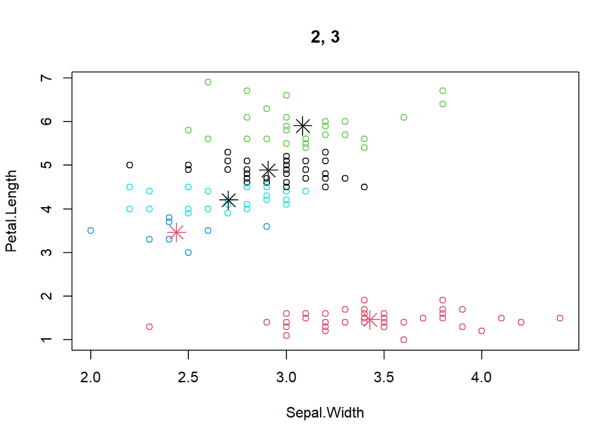

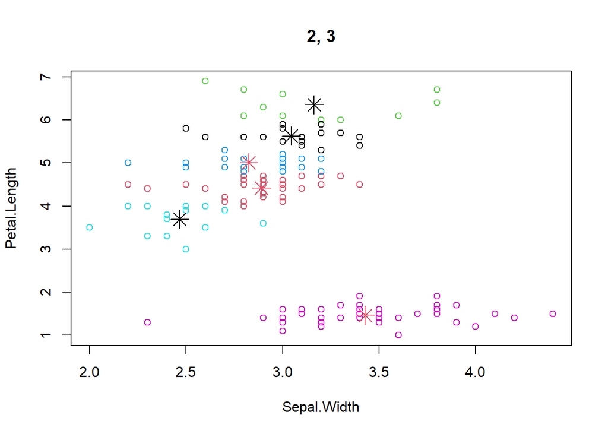

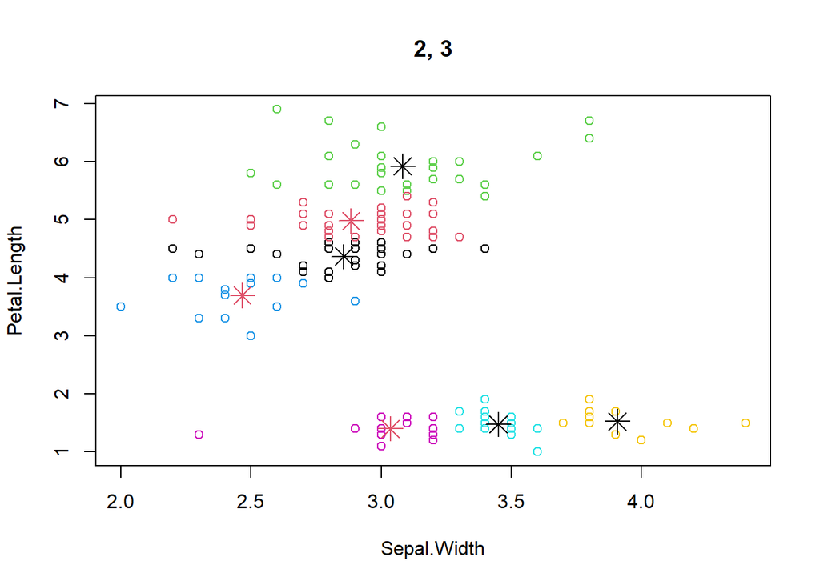

```
## [1] 6
```

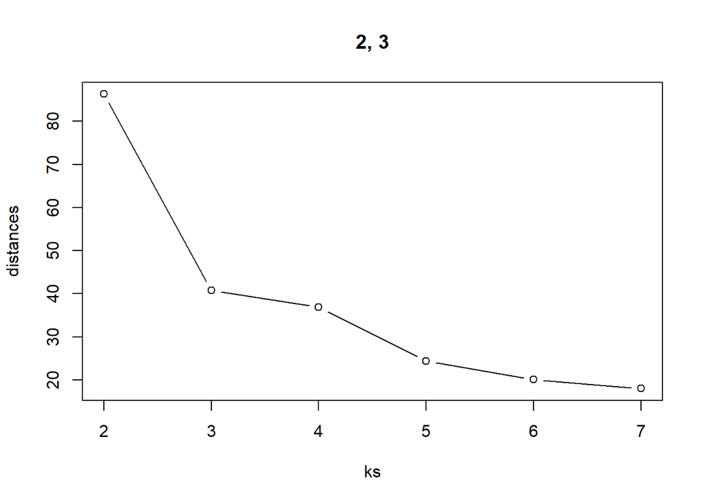

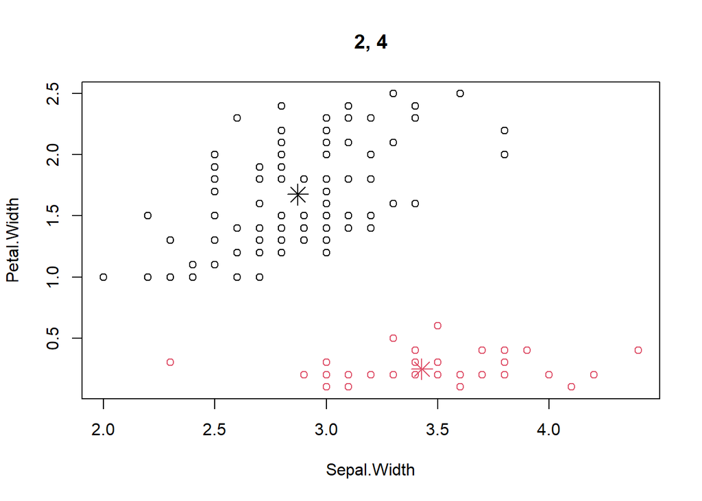

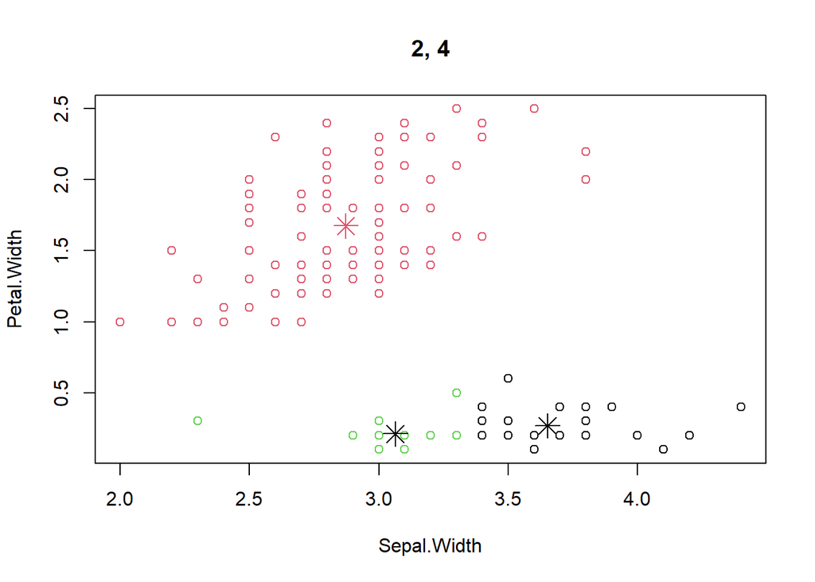